# Suicides overview from 1985 to 2016

Vladimir Vranjes

6/12/2020

# Introduction

My name is Vladimir Vranješ and in this project I will present you overview of suicides that happend from 1985-2016.Reason I picked this dark topic because of that this is ongoing problem that seems never to end and I wanted to see how many lives have it taken .

# Presentation and description of the problem

Suicide is the act of intentionally causing one’s own death.It can occur as result of mental disorders ,financial difficulties,bullying etc . Suicide is problem that is following humankind through centuries.It is problem that is very hard to deal with and it is topic that humans try to figure out for a very long time . It is one of the most frequent causes of the death in the world and the reason I chosed this time span is because this is period that human population grew most .

# Presentation of data

```r
Data<-read.csv(file = "master.csv")%>%rename(CountryName = ï..country)  ## Here I also  renamed the first column
Data%>%head(5)
```

```
##   CountryName year    sex         age suicides_no population suicides.100k.pop
## 1     Albania 1987   male 15-24 years          21     312900              6.71
## 2     Albania 1987   male 35-54 years          16     308000              5.19
## 3     Albania 1987 female 15-24 years          14     289700              4.83
## 4     Albania 1987   male   75+ years           1      21800              4.59
## 5     Albania 1987   male 25-34 years           9     274300              3.28
##   country.year HDI.for.year gdp_for_year.... gdp_per_capita....      generation
## 1  Albania1987           NA    2,156,624,900                796    Generation X
## 2  Albania1987           NA    2,156,624,900                796          Silent
## 3  Albania1987           NA    2,156,624,900                796    Generation X
## 4  Albania1987           NA    2,156,624,900                796 G.I. Generation
## 5  Albania1987           NA    2,156,624,900                796         Boomers
```

# Number of suicides per continent

```r
Data$continent<-countrycode(sourcevar = Data[, "CountryName"],
                              origin = "country.name",
                              destination = "continent")    # Here i used package countrycode to Add another column to split out Countries by continents

ContinentData<-Data%>%select(continent,suicides_no)%>%group_by(continent)%>%summarise(sum(suicides_no))

names(ContinentData)[2]<-"NumberOfSuicides"

ContinentData%>%arrange(desc(NumberOfSuicides))%>%top_n(4)   # Here i Excluded Africa because of lack of informations
```

```
## # A tibble: 4 x 2
##   continent NumberOfSuicides
##   <chr>                <int>
## 1 Europe             3408447
## 2 Americas           1787619
## 3 Asia               1456148
## 4 Oceania              84851
```

# Top 10 Countries with most suicides

```r
Data1<-Data%>%select(CountryName,suicides_no)%>%group_by(CountryName)%>%arrange(desc(CountryName))%>%summarise(sum(suicides_no))
names(Data1)[2]<-"NumberOfSuicides"
Data1%>%arrange(desc(NumberOfSuicides))%>%top_n(10)
```

```
## # A tibble: 10 x 2
##    CountryName        NumberOfSuicides
##    <fct>                         <int>
##  1 Russian Federation          1209742
##  2 United States               1034013
##  3 Japan                        806902
##  4 France                       329127
##  5 Ukraine                      319950
##  6 Germany                      291262
##  7 Republic of Korea            261730
##  8 Brazil                       226613
##  9 Poland                       139098
## 10 United Kingdom               136805
```

# Top 10 countries with least suicides

```r
Data1<-Data%>%select(CountryName,suicides_no)%>%group_by(CountryName)%>%arrange(desc(CountryName))%>%summarise(sum(suicides_no))%>%ungroup()
names(Data1)[2]<-"NumberOfSuicides"
Data1%>%arrange(desc(NumberOfSuicides))%>%top_n(-10)
```

```
## # A tibble: 10 x 2
##    CountryName           NumberOfSuicides
##    <fct>                            <int>
##  1 Kiribati                            53
##  2 Cabo Verde                          42
##  3 Grenada                             38
##  4 Oman                                33
##  5 Macau                               27
##  6 Maldives                            20
##  7 Antigua and Barbuda                 11
##  8 San Marino                           4
##  9 Dominica                             0
## 10 Saint Kitts and Nevis                0
```

**It is interesting here that Dominica and Saint Kitts and Nevis did not have one suicide in span of 31 years**

# Higest rate of suicide between two sexes

```r
TotalSuicides<-Data%>%select(suicides_no)%>%sum()

Data2<-Data%>%select(sex,suicides_no)%>%group_by(sex)%>%summarise((sum(suicides_no)/TotalSuicides)*100)
names(Data2)[2]<-"NumberOfSuicides"

Data2
```

```
## # A tibble: 2 x 2
##   sex    NumberOfSuicides
## * <fct>             <dbl>
## 1 female             23.1
## 2 male               76.9
```

**Here we see that from Total number of sucides which is over 6 milions, about 76.9 % are males and 23.1 % are females**

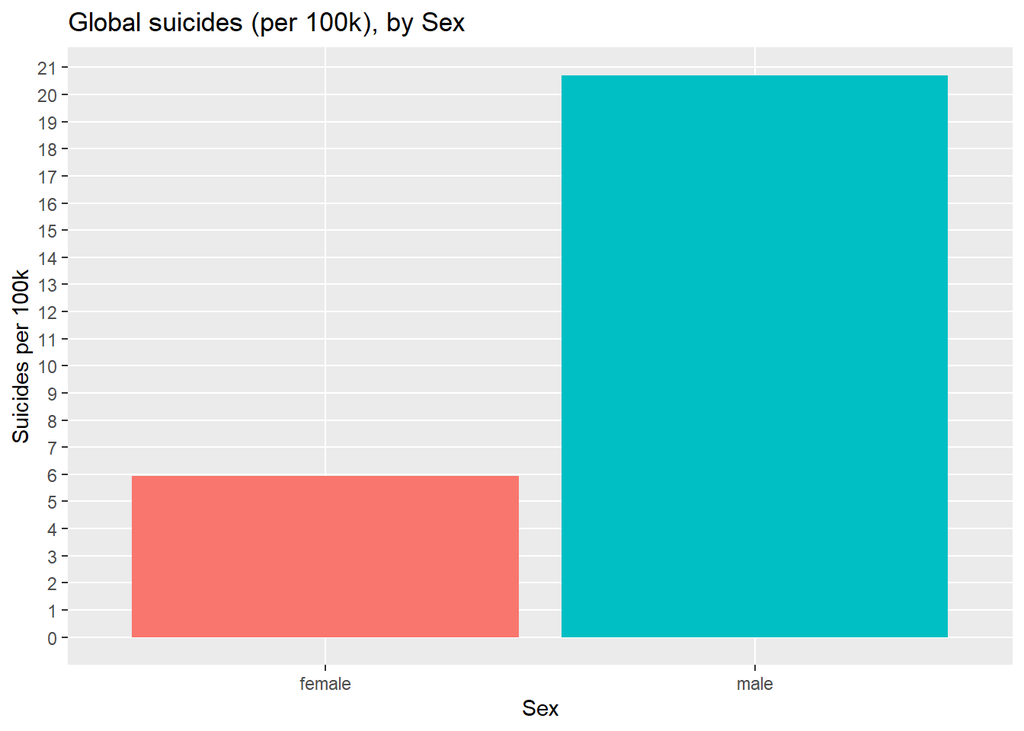

```r
 Data %>%
  group_by(sex) %>%
  summarize(suicide_per_100k = (sum(as.numeric(suicides_no)) / sum(as.numeric(population))) * 100000) %>%
ggplot(aes(x = sex, y = suicide_per_100k, fill = sex)) +
  geom_bar(stat = "identity") +
  labs(title = "Global suicides (per 100k), by Sex",
       x = "Sex",
       y = "Suicides per 100k") +
  theme(legend.position = "none") +
  scale_y_continuous(breaks = seq(0, 25), minor_breaks = F)
```

**Here I also visualised the differnce in numbers per 100 k of population between two of sexes**

# 10 countries with highest average rate of suicides per 100 K of population

```r
DATA<-Data%>%select(CountryName,suicides.100k.pop)%>%group_by(CountryName)%>%
  summarise(mean(suicides.100k.pop))

names(DATA)[2]<-"SuicidePer100Kpop"

DATA%>%arrange(desc(SuicidePer100Kpop))%>%top_n(10)
```

```
## # A tibble: 10 x 2
##    CountryName        SuicidePer100Kpop
##    <fct>                          <dbl>
##  1 Lithuania                       40.4
##  2 Sri Lanka                       35.3
##  3 Russian Federation              34.9
##  4 Hungary                         32.8
##  5 Belarus                         31.1
##  6 Kazakhstan                      30.5
##  7 Latvia                          29.3
##  8 Slovenia                        27.8
##  9 Estonia                         27.3
## 10 Ukraine                         26.6
```

# Graphical presentation of Global suicides (per 100k )

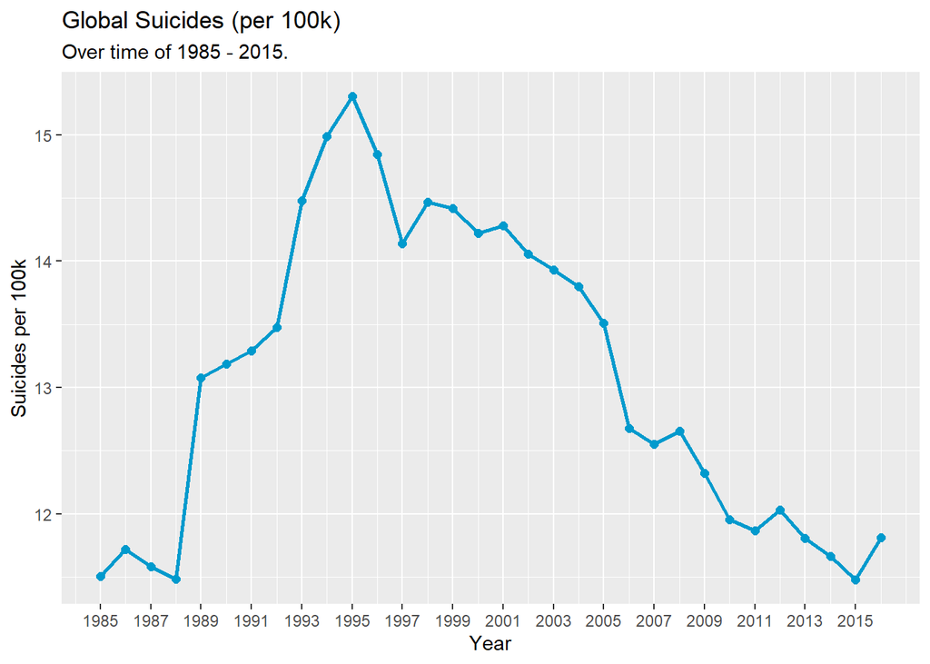

```r
Data %>%
  group_by(year) %>%
  summarize(population = sum(population),
            suicides = sum(suicides_no),
            suicides_per_100k = (suicides / population) * 100000) %>%
  ggplot(aes(x = year, y = suicides_per_100k)) +
  geom_line(col = "deepskyblue3", size = 1) +
  geom_point(col = "deepskyblue3", size = 2) +

  labs(title = "Global Suicides (per 100k)",
       subtitle = "Over time of 1985 - 2015.",
       x = "Year",
       y = "Suicides per 100k") +
  scale_x_continuous(breaks = seq(1985, 2015, 2)) +
  scale_y_continuous(breaks = seq(10, 20))
```

# Graphical presentation of global suicides per 100 k by Age

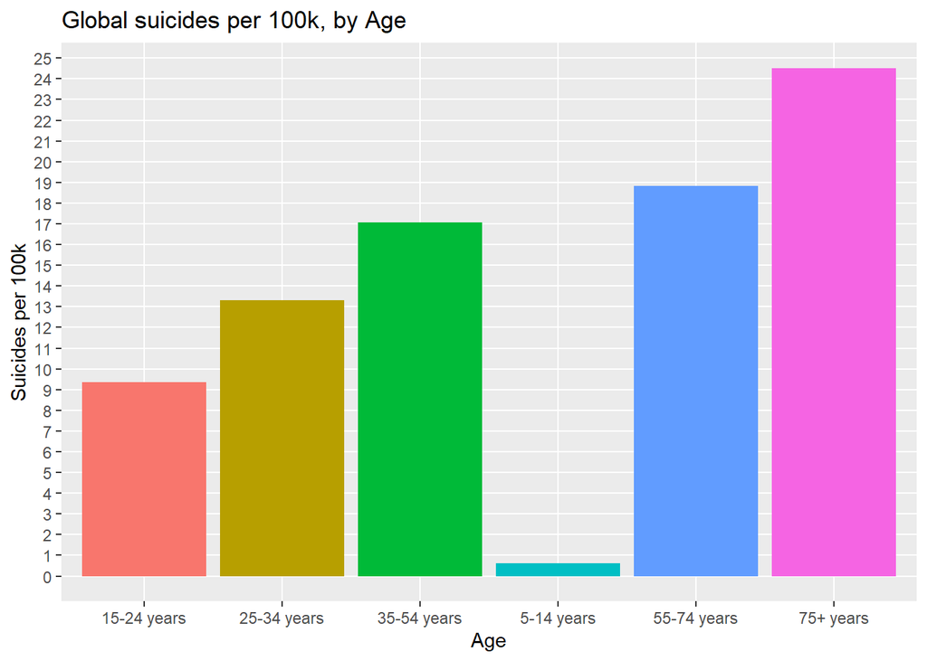

```r
 Data %>%
  group_by(age) %>%
  summarize(suicide_per_100k = (sum(as.numeric(suicides_no))/sum(as.numeric(population)))*100000) %>%
  ggplot(aes(x=age, y=suicide_per_100k, fill = age)) +
  geom_bar(stat = "identity") +
  labs(title = "Global suicides per 100k, by Age",
       x = "Age",
       y = "Suicides per 100k") +
  theme(legend.position = "none") +
  scale_y_continuous(breaks = seq(0, 25, 1), minor_breaks = F)
```

# Number of suicides for each generation

```r
Data3<-Data%>%select(generation,suicides_no)%>%group_by(generation)%>%summarise(sum(suicides_no))

names(Data3)[2]<-"NumberOfSuicides"

Data3%>%arrange(desc(NumberOfSuicides))
```

```
## # A tibble: 6 x 2
##   generation      NumberOfSuicides
##   <fct>                      <int>
## 1 Boomers                  2284498
## 2 Silent                   1781744
## 3 Generation X             1532804
## 4 Millenials                623459
## 5 G.I. Generation           510009
## 6 Generation Z               15906
```

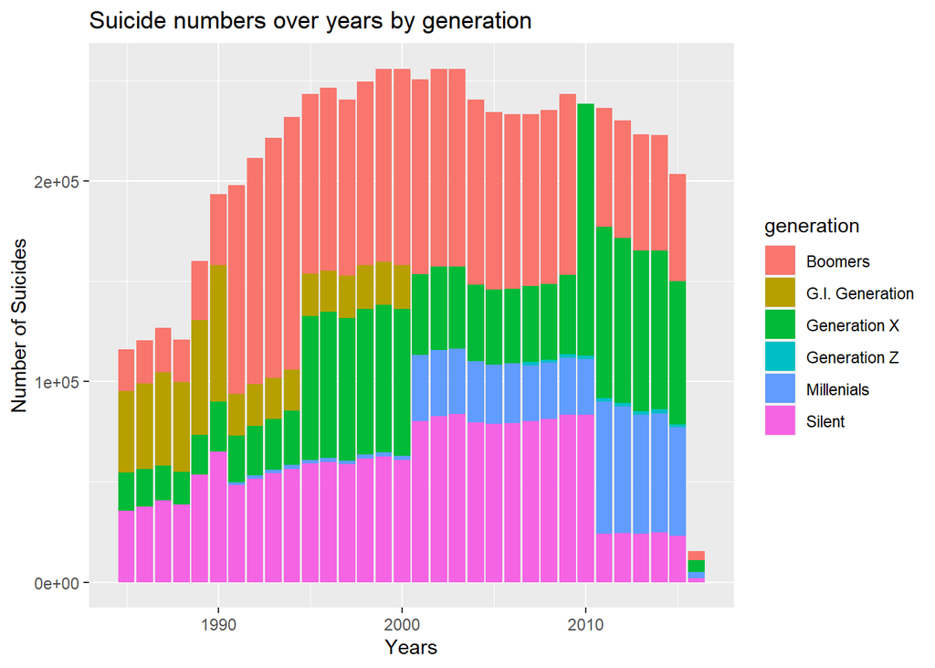

```r
Data%>%ggplot(aes(x=year,y=suicides_no,fill=generation))+geom_bar(stat = "identity")+
  labs(title = "Suicide numbers over years by generation",
                x="Years",
                y="Number of Suicides")
```

# Ten years with most suicides

```r
Data4<-Data%>%select(year,suicides_no)%>%group_by(year)%>%summarise(sum(suicides_no))

names(Data4)[2]<-"NumberOfSuicides"
Data4%>%arrange(desc(NumberOfSuicides))%>%top_n(10)
```

```
## # A tibble: 10 x 2
##     year NumberOfSuicides
##    <int>            <int>
##  1  1999           256119
##  2  2002           256095
##  3  2003           256079
##  4  2000           255832
##  5  2001           250652
##  6  1998           249591
##  7  1996           246725
##  8  1995           243544
##  9  2009           243487
## 10  2004           240861
```

# Total number of suicides over each year

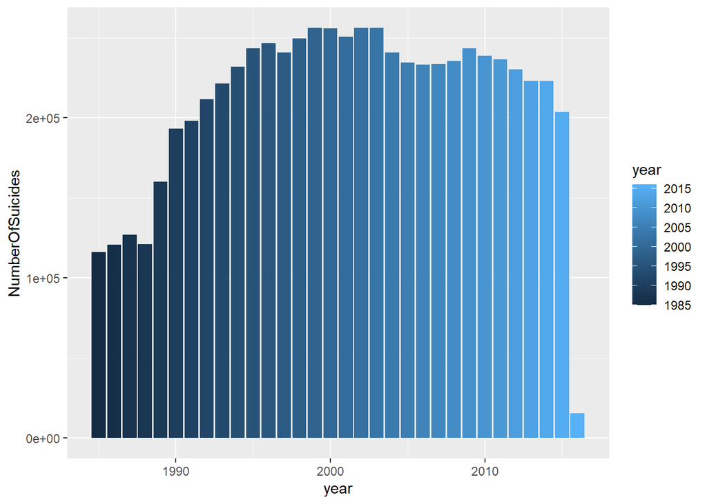

```r
Data5<-Data%>%select(year,suicides_no)%>%group_by(year)%>%summarise(sum(suicides_no))

names(Data5)[2]<-"NumberOfSuicides"
Data5%>%arrange(desc(NumberOfSuicides))%>%ggplot(aes(x=year,y=NumberOfSuicides,fill=year))+geom_bar(stat = "identity")
```

# Geographical map of the suicide rates

```r
country <- Data %>%
  group_by(CountryName) %>%
  summarize(suicide_per_100k = (sum(as.numeric(suicides_no)) / sum(as.numeric(population))) * 100000)

countrydata <- joinCountryData2Map(country, joinCode = "NAME", nameJoinColumn = "CountryName")
```

```
## 99 codes from your data successfully matched countries in the map
## 2 codes from your data failed to match with a country code in the map
## 144 codes from the map weren't represented in your data
```

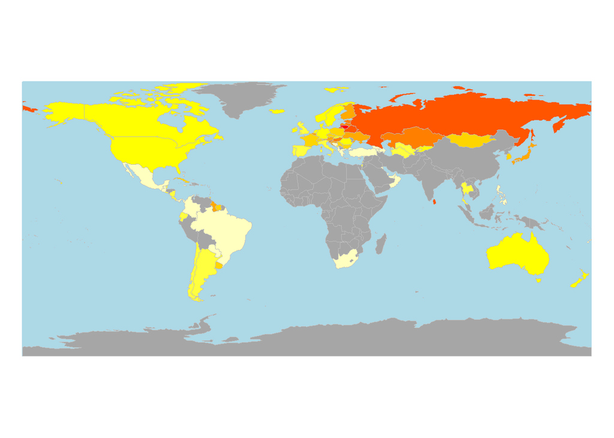

```r
par(mar=c(0, 0, 0, 0)) # margins

mapCountryData(countrydata,
nameColumnToPlot="suicide_per_100k",
mapTitle="",
colourPalette = "heat",
oceanCol="lightblue",
missingCountryCol="grey65",
addLegend = FALSE,
catMethod = "pretty")
```

**Here is a geographical heat map of the suicide rates between the timeframe of this analysis - note the lack of data for Africa and Asia**

# Conclusion

By analizing this data we came across that in 30 years over 6 milion people took it`s own life . In that number 76 percent were males and 24 percent were females.Generation with most suicides were Bommers and generation with least suicides were Children . Year with most suicides were 1999 and countries with most suicides were Russian Federation followed by USA (these two countries were only that had over milion suicides ). Country with highest average rate of suicides per 100 k of population is Lithuania . One interesting fact we came across is that Dominica and Saint Kitts and Nevis did not have any suicides in span of 30 years which is pretty amazing . Continent with most suicides in this period of time is Europe with 3.4 milion suicides in which Russia takes more than 1/3 of complete number .

# References

*References used to make this Data that was used for analysis*

United Nations Development Program. (2018). Human development index (HDI). Retrieved from http://hdr.undp.org/en/indicators/137506

World Bank. (2018). World development indicators: GDP (current US$) by country:1985 to 2016. Retrieved from http://databank.worldbank.org/data/source/world-development-indicators#

[Szamil]. (2017). Suicide in the Twenty-First Century [dataset]. Retrieved from https://www.kaggle.com/szamil/suicide-in-the-twenty-first-century/notebook

World Health Organization. (2018). Suicide prevention. Retrieved from http://www.who.int/mental_health/suicide-prevention/en/

*Data found on :* https://www.kaggle.com/